# RforDataScienceCh1

## 3. What does show.legend = FALSE do? What happens if you remove it? Why do you think I used it earlier in the chapter?

You are actually asking a bizarre question to point out the interesting feature of ggplot that I think you intended to point out. Firstly, it’s quite apparent what it does, it makes it so that ggplot surpresses whatever automated legend would have appeared in the graph. What is more interesting, more illuminating, is the second component of this question. IF, for example, we used the *group* aesthetic, ggplot would create separete graphical objects for the grouping we assigned, but unlike the automatic grouping that occurs when we assign an aesthetic to a discrete variable, a direct assignment to the group aesthetic would create no automatic legend.

Compare graphs 2, 3, and 4 below.

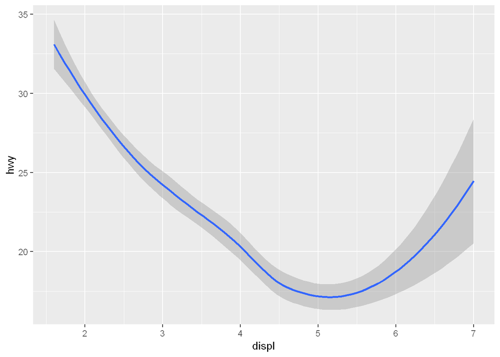

```r
p <- ggplot(data = mpg)

p + geom_smooth(mapping = aes(x = displ, y = hwy))
```

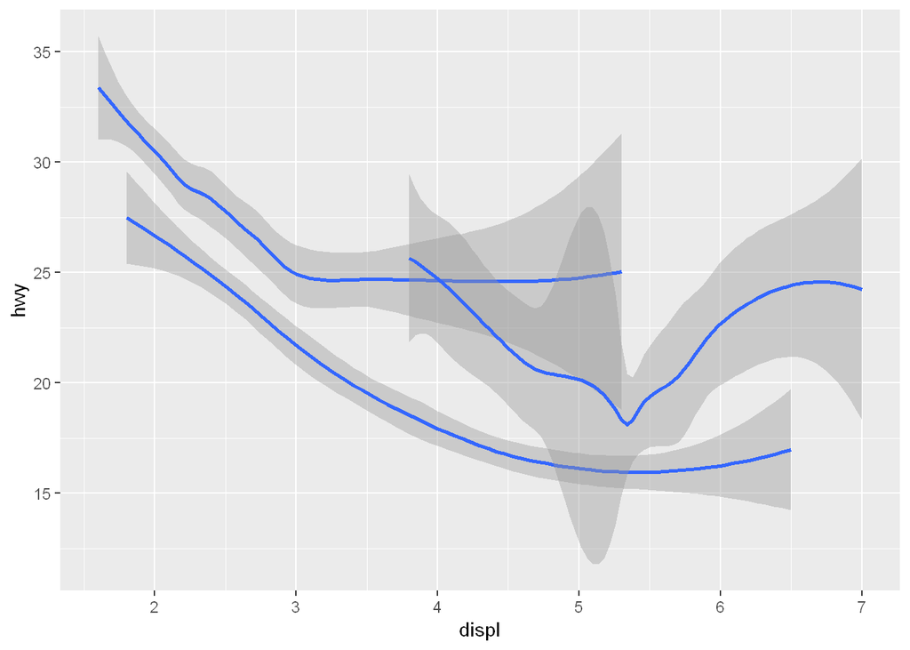

```r
p + geom_smooth(mapping = aes(x = displ, y = hwy, group = drv))
```

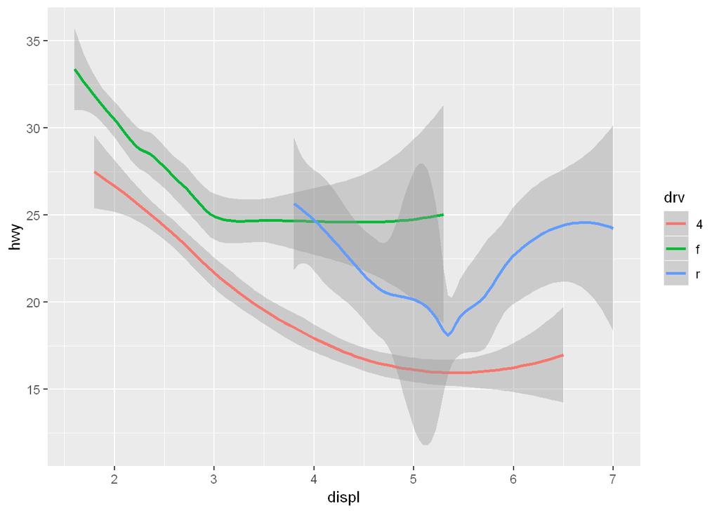

```r
p + geom_smooth(mapping = aes(x = displ, y = hwy, color = drv))
```

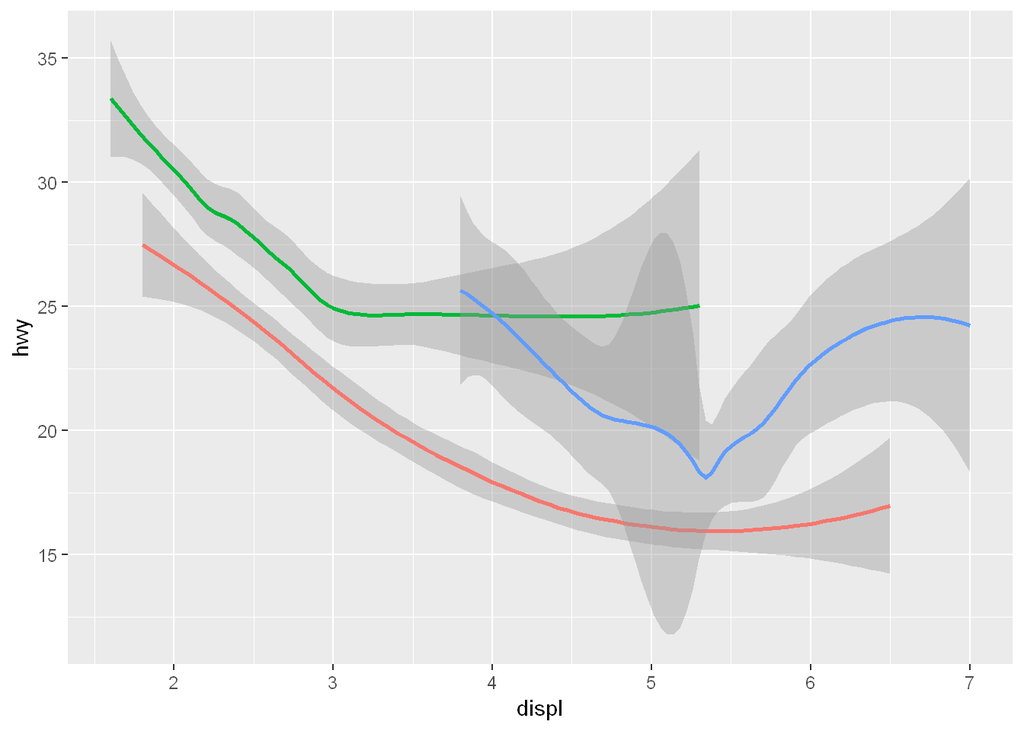

```r
p + geom_smooth(mapping = aes(x = displ, y = hwy, color = drv),
                show.legend = FALSE
)
```

## 4. What does the se argument in geom_smooth do?

Setting it to False removes the bands around the line that represent the standard error of the aproximation which the smooth line represents.

## 5. Will these two graphs look different? Why/why not?

-1 ggplot(data = mpg, mapping = aes(x = displ, y = hwy)) + geom_point() + geom_smooth() -2  
ggplot() + geom_point( data = mpg, mapping = aes(x = displ, y = hwy) ) + geom_smooth( data = mpg, mapping = aes(x = displ, y = hwy) )

No, these graphs will not look different. Why? Well, assigning aesthetics and mappings to the ggplot function amounts to assigning global settings to the overall graph, where as assigning these things to geometry functions, like geom_point, merely overrides the global setting for that particular layer. Now in this example, the first graph has global settings which are simply reproduced by the local settins of the individual geometry layers in the second graph. Let us now test my hypothetical musings.

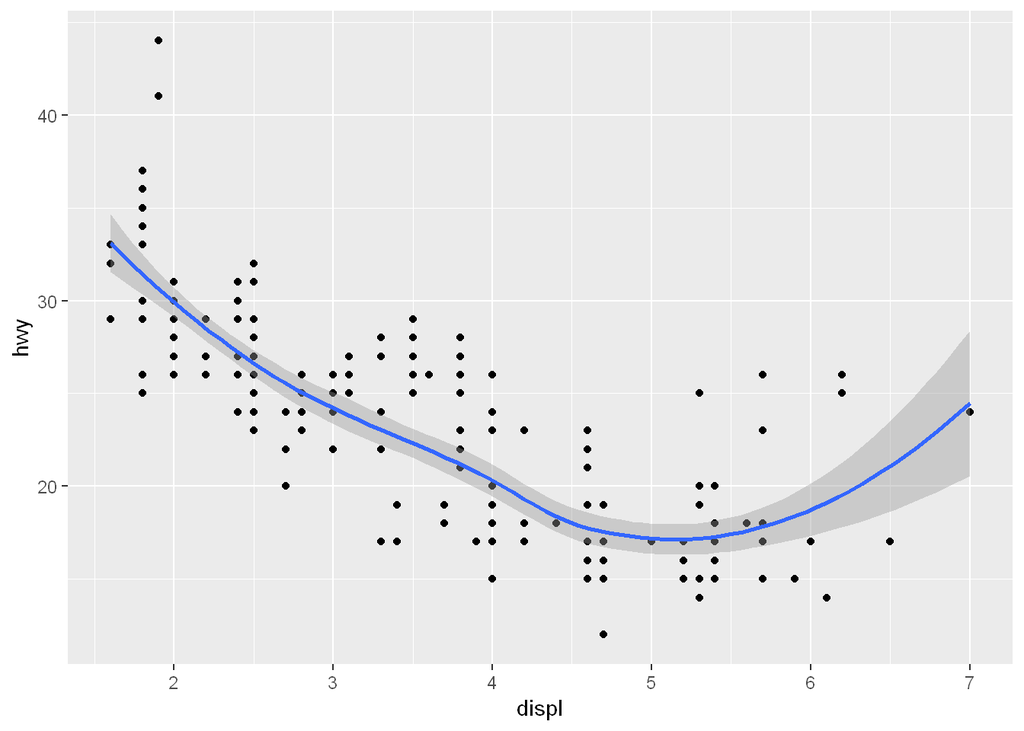

```r
#-1
ggplot(data = mpg, mapping = aes(x = displ, y = hwy)) +
  geom_point() +
  geom_smooth()
```

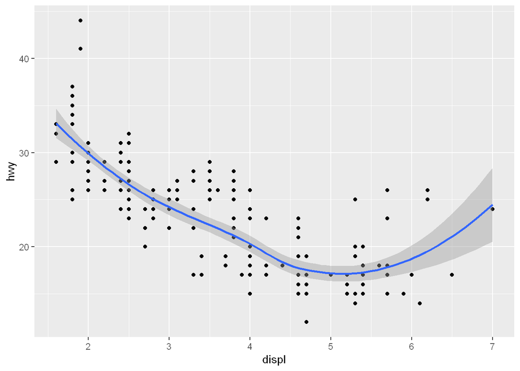

```r
#-2
ggplot() +
  geom_point(
    data = mpg,
    mapping = aes(x = displ, y = hwy)
  ) +
  geom_smooth(
    data = mpg,
    mapping = aes(x = displ, y = hwy)
  )
```

Indded, my hypothesis was proven exactly correct, as the graphs are themselves exactly equal to eachother.

## 6. Re-create the R code necessary to generate the following graphs

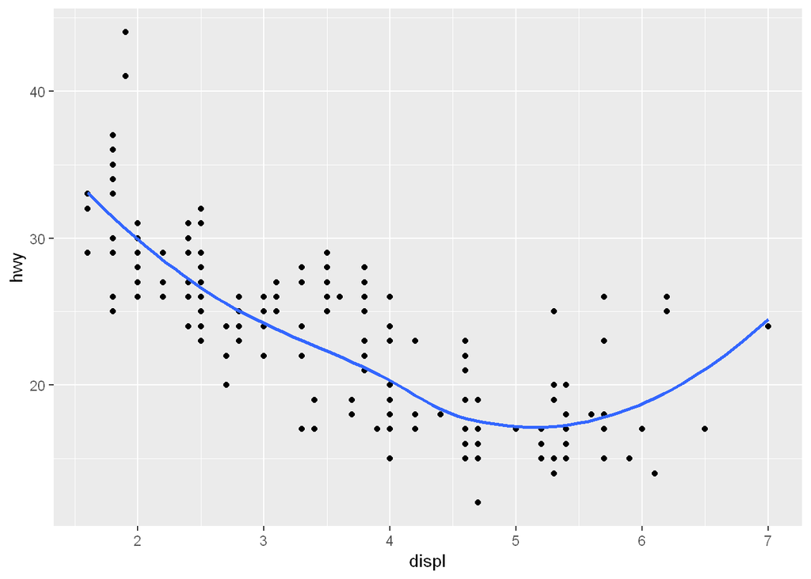

```r
p <- ggplot( data = mpg, aes( x = displ, y = hwy))

q1 <- p + geom_point()
#TOP LEFT
q1 + geom_smooth(se = FALSE)
```

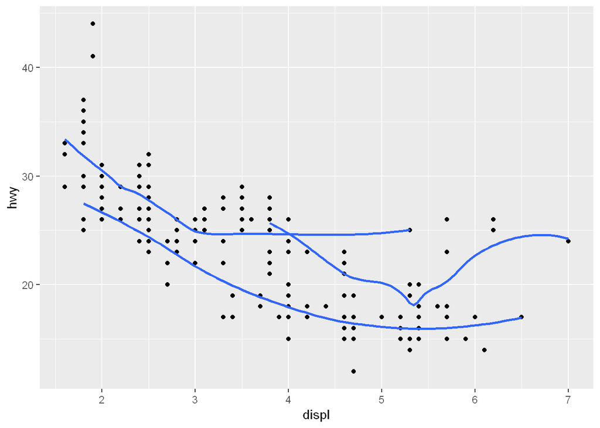

```r
#TOP RIGHT
q1 + geom_smooth(se = FALSE, mapping = aes( x = displ, y = hwy, group = drv))
```